# Exploring US Wages Across Occupations

### By Sarah Schmidt

[figure not shown]

## Exploring our data and begining to ask questions

```python
genderwage = pd.read_csv(datafile)
genderwage.head(1)
```

|  | Occupation | All_workers | All_weekly | M_workers | M_weekly | F_workers | F_weekly |
| --- | --- | --- | --- | --- | --- | --- | --- |
| 0 | ALL OCCUPATIONS | 109080 | 809 | 60746 | 895 | 48334 | 726 |

### Others have already asked "IS there a wage gap?" and "How big is the wage gap?" I wanted to ask a different question.

### My question is can we predict Occupation Category using wage, gender, share of females in the field, and if that field is male dominated or has a significant wage gap?

## Uncovering occupation categories and assigning labels to rows

```python
categories = []
for i in genderwage['Occupation']:
    if i.isupper()==True:
        categories.append(i)

genderwage.insert(1, 'Occupation_Category', 0)

cat_count = -1
index_copy = pd.Index(list(genderwage['Occupation']))
for x in genderwage['Occupation']:
    current_index = index_copy.get_loc(x)
    genderwage.iloc[current_index,
                    genderwage.columns.get_loc('Occupation_Category')] = cat_count
    if x.isupper():
        cat_count = cat_count + 1
        genderwage.iloc[current_index,
                        genderwage.columns.get_loc('Occupation_Category')] = cat_count

genderwage.insert(1, 'Occupation_Category_label', 0)

cat_label = 'nothing'
for x in genderwage['Occupation']:
    current_index = index_copy.get_loc(x)
    genderwage.iloc[current_index,
                    genderwage.columns.get_loc('Occupation_Category_label')] = cat_label
    if x.isupper():
        cat_label = x
        genderwage.iloc[current_index,
                        genderwage.columns.get_loc('Occupation_Category_label')] = cat_label
```

## Combining occupation labels to facilitate modeling

```python
# combine categories
cleanedgenderwage.loc[cleanedgenderwage['Occupation_Category_label'] == 'HEALTHCARE SUPPORT', 'Occupation_Category_label'] = 'HEALTHCARE'
cleanedgenderwage.loc[cleanedgenderwage['Occupation_Category_label'] == 'HEALTHCARE PROFESSIONAL', 'Occupation_Category_label'] = 'HEALTHCARE'

cleanedgenderwage.loc[cleanedgenderwage['Occupation_Category_label'] == 'AGRICULTURAL', 'Occupation_Category_label'] = 'INFRASTRUCTURE SUPPORT'
cleanedgenderwage.loc[cleanedgenderwage['Occupation_Category_label'] == 'MAINTENANCE', 'Occupation_Category_label'] = 'INFRASTRUCTURE SUPPORT'
cleanedgenderwage.loc[cleanedgenderwage['Occupation_Category_label'] == 'GROUNDSKEEPING', 'Occupation_Category_label'] = 'INFRASTRUCTURE SUPPORT'
cleanedgenderwage.loc[cleanedgenderwage['Occupation_Category_label'] == 'TRANSPORTATION', 'Occupation_Category_label'] = 'INFRASTRUCTURE SUPPORT'

cleanedgenderwage.loc[cleanedgenderwage['Occupation_Category_label'] == 'EDUCATION', 'Occupation_Category_label'] = 'SOCIAL SERVICE'

cleanedgenderwage.loc[cleanedgenderwage['Occupation_Category_label'] == 'PROTECTIVE SERVICE', 'Occupation_Category_label'] = 'OTHER'
cleanedgenderwage.loc[cleanedgenderwage['Occupation_Category_label'] == 'SERVICE', 'Occupation_Category_label'] = 'OTHER'
cleanedgenderwage.loc[cleanedgenderwage['Occupation_Category_label'] == 'ARTS', 'Occupation_Category_label'] = 'OTHER'
cleanedgenderwage.loc[cleanedgenderwage['Occupation_Category_label'] == 'LEGAL', 'Occupation_Category_label'] = 'OTHER'
cleanedgenderwage.loc[cleanedgenderwage['Occupation_Category_label'] == 'ENGINEERING', 'Occupation_Category_label'] = 'OTHER'
cleanedgenderwage.loc[cleanedgenderwage['Occupation_Category_label'] == 'SCIENCE', 'Occupation_Category_label'] = 'OTHER'
```

# Distribution of Employees

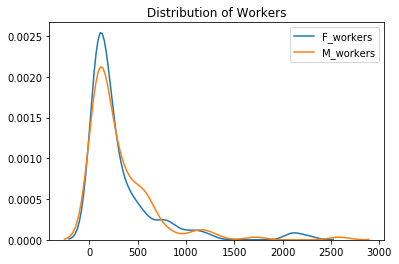

```python
sns.kdeplot(data=cleanedgenderwage['F_workers'])
sns.kdeplot(data=cleanedgenderwage['M_workers'])
plt.title('Distribution of Workers')
plt.show()
```

# Next the distribution of wages

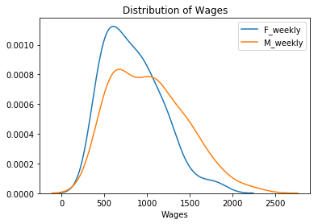

```python
sns.kdeplot(data=cleanedgenderwage['F_weekly'])
sns.kdeplot(data=cleanedgenderwage['M_weekly'])
plt.title('Distribution of Wages')
plt.xlabel('Wages')
plt.show()
```

# Mens and Womens wages by field wages

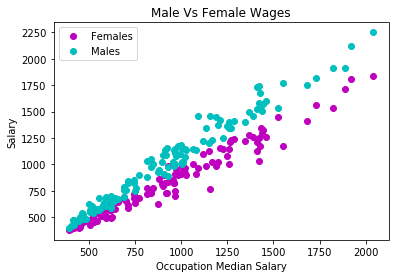

```python
# look at female wages vs male wages on a scatter plot
plt.plot(cleanedgenderwage['All_weekly'],
         cleanedgenderwage['F_weekly'], 'o', color='m')
plt.plot(cleanedgenderwage['All_weekly'],
         cleanedgenderwage['M_weekly'], 'o', color='c')
plt.xlabel('Occupation Median Salary')
plt.legend(['Females','Males'])
plt.title('Male Vs Female Wages')
plt.ylabel('Salary')
plt.show()
```

## New features from old

```python
cleanedgenderwage['WageGap_as_Ratio'] = cleanedgenderwage['F_weekly'] / cleanedgenderwage['M_weekly']
cleanedgenderwage['Significant_wage_gap'] = np.where(cleanedgenderwage['WageGap_as_Ratio'] > .85, 0, 1)

cleanedgenderwage['F_share'] = cleanedgenderwage['F_workers'] / cleanedgenderwage['All_workers']
cleanedgenderwage['Male_Dominated'] = np.where(cleanedgenderwage['F_share'] > .45, 0, 1)
```

## Distribution of Wage Gap

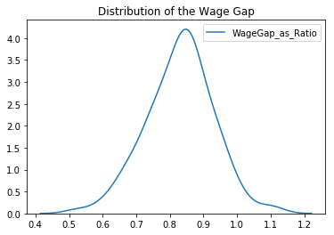

```python
sns.kdeplot(data=cleanedgenderwage['WageGap_as_Ratio'])
plt.title('Distribution of the Wage Gap')
plt.show()
```

# Female Share per Occupation

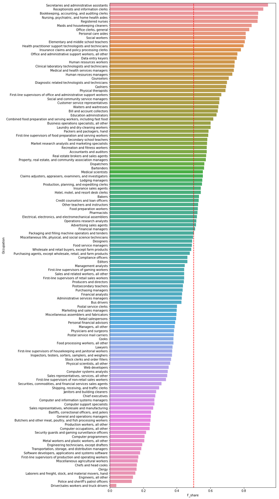

```python
# Now lets look at the ratio of workers
plt.figure(figsize=((10,30)))
sns.barplot(x='F_share',
            y='Occupation',
            data=cleanedgenderwage.sort_values('F_share', ascending=False))
plt.axvline(x=.5, color='red', linestyle='--') # equality at 50%
plt.show()
```

# Wage Ratio By Occupation

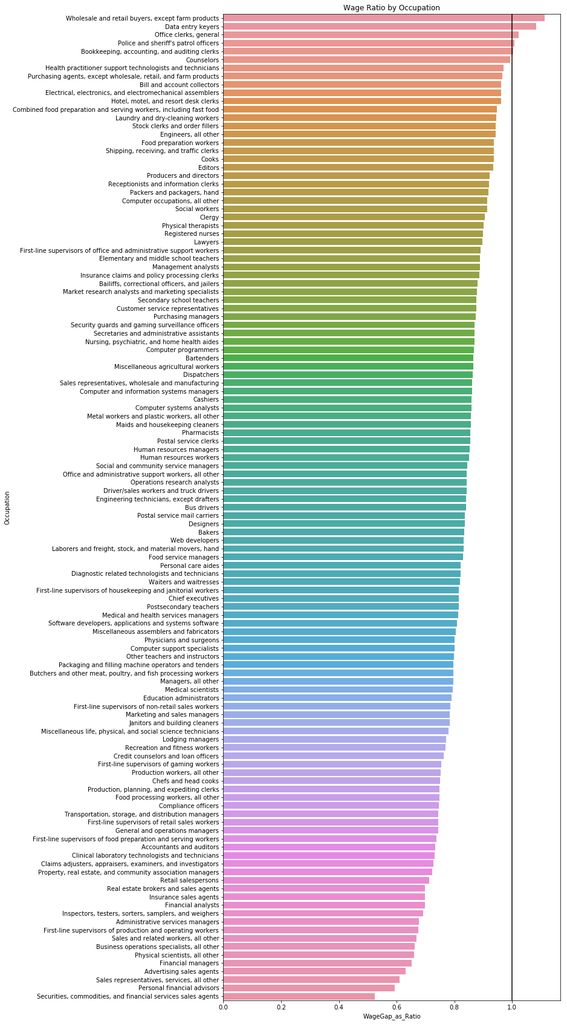

```python
# Look at wage ratio by occupation
plt.figure(figsize=((10,30)))
sns.barplot(x='WageGap_as_Ratio',
            y='Occupation',
            data=cleanedgenderwage.sort_values('WageGap_as_Ratio',
                                               ascending=False))
plt.axvline(x=1, color='black', linestyle='solid')
plt.title('Wage Ratio by Occupation')
plt.show()
```

# Modeling the Data

The question I'm asking is a classification question, so I tested:

```
- Logistic Regression Classifier  (A Classic first step classifier)
- Decision Tree Classifier (a different kind of classifier than a regression)
- Random Forest Classifier (multiple decision trees together as a classifier)
- Extra Trees Ensemble Classifier (more trees might be better)
- Support Vector Classifier (a third kind of classifier)
- Gradient Boosting Classifier (a  fourth kind of classifier)
```

## Create the dictionary of each estimators parameters to check, set up the different estimators, set up list of estimators and list of params.

```python
log_param = {'tol': (.01, .5, 1, 5),
             'C': (.01, .5, 1, 5),
             'solver': ('newton-cg', 'lbfgs', 'sag')}
forest_type_param = {'n_estimators': (100, 200, 300),
                       'criterion': ('gini', 'entropy'),
                       'max_depth': (2, 3, 5)}
dtree_param = {'criterion': ('gini', 'entropy'),
                       'max_depth': (2, 3, 5)}
gradient_param = {'learning_rate': (.01, .5, 1),
                   'n_estimators':(100, 200, 300),
                   'max_depth':(2, 3, 4, 5, 6)}
svc_param = {'C': (.1, .5, 1, 5),
             'kernel': ('linear', 'poly', 'rbf', 'sigmoid'),
             'degree': (2, 3, 4, 5),
             'gamma': (1, 2, 3)}

# got my estimators
logr = linear_model.LogisticRegression()
gradient = ensemble.GradientBoostingClassifier()
extree = ensemble.ExtraTreesClassifier()
dtree = tree.DecisionTreeClassifier()
svc = SVC()
forest = ensemble.RandomForestClassifier()

estimators = [logr,
              gradient,
              extree,
              dtree,
              svc,
              forest]
params = [log_param,
          gradient_param,
          forest_type_param,
          dtree_param,
          svc_param,
          forest_type_param]
```

## Use GridSearchCV to find the best estimator and it't hyperparameters

```python
from sklearn.model_selection import GridSearchCV

def check_grid(estimator, params, X, y):
    grid_classifier = GridSearchCV(estimator=estimator, param_grid=params)
    grid_classifier.fit(X, y)
    grid_score = grid_classifier.score(X, y)
    return (grid_classifier, grid_score)
```

## Assign our variables, scale our X, use SMOTE to expand our training data

```python
scaler = StandardScaler()
columns = ['M_weekly',
           'F_weekly',
           'Male_Dominated',
           'Significant_wage_gap',
           'WageGap_as_Ratio',
           'F_share']

X = cleanedgenderwage[columns]

X_std = StandardScaler().fit_transform(X)
y = cleanedgenderwage['Occupation_Category_label']

X_train, X_test, y_train, y_test = train_test_split(X_std,
                                                    y,
                                                    test_size=.4,
                                                    random_state=64)
# using random state so I can rerun cells
# and not accidentally change the number of instances in my classes

X_smote, y_smote = smote.fit_sample(X_train, y_train)
```